# Cesar R workshop: welcome to the tidyverse

Alex Slavenko & Evatt Chrigwin

22/09/2023

# Welcome!

This workshop is designed to bring your data wrangling skills to the next level, by utilising all of the capabilities of **THE TIDYVERSE**.

[figure not shown]

The `tidyverse` is a collection of R packages designed for data science. They all share an underlying design philosophy, grammar, and data structures. They all work together and make data wrangling a lot easier compared to base R, and can also integrate easily with lots of cool analysis and visualisation tools.

If you've completed the Cesar liteRacy quiz, you should already have a basic familiarity with R, and have the required packages installed.

Now, without further ado,

[figure not shown]

### Load all following packages: `tidyr`, `dplyr`, `magrittr`, `readr`, `ggplot2`

You should have all of these packages installed from the liteRacy quiz, but if not install them using `install.package("package_name")`.

```r
#load packages
library(tidyr)
library(dplyr)
library(readr)
library(ggplot2)
```

### Set your working directory for today

Replace "YOUR_PATHWAY" with the pathway to whichever directory you're using today.

```r
setwd("YOUR_PATHWAY")
```

Don't worry, there's a solution for you.

One of the many cool features of RStudio is the ability to create R Projects, by clicking File -> New Project...

Projects are self-contained directories. In their most basic form they come with an .Rproj file, which you use to load an R session with the working directory set to the project folder. As long as all of your code and data are contained within this folder, you won't need to mess around with working directories ever again. Not only does this make your own work process neater (because every project has its own data and code compartmentalised), it is also useful when you're working with collaborators - simply send them the entire project folder, complete with the data, code, and .Rproj file, and they have plug-and-play code ready that will work on their system.

Some caveats:

- Even when using projects, code might fail to run on a different computer if there are big differences in versions of R or required packages, and some package installation might be necessary. So it's not a perfect solution for compartmentalising and sharing code.
- Sending data may be a problem if your data take up a lot of space.
- Likewise, multiple projects can use the same underlying data, and if these data take up a lot of space (like spatial data) then creating a copy for each project can really eat up your computer's resources. In these cases, it might be better to keep these data in a separate folder and use the full pathway to import them in your scripts - but then you're back to this not being easy to share with collaborators.

We've got us a nifty little dataset showing results of a bioassay performed on multiple populations. Our goal today is to gain some insights around survival dynamics, and eventually create a plot of survival as a function of growth. However, as we'll soon see, there are some steps that need to be taken along the way.

### Import the dataset (Play_data.csv) and store it as an object named `data1`.

```r
data1 <- read.csv('Play_data.csv')
```

## Data exploration and manipulation

### Have a look at your data.

Are your data long or wide?

A brief refresher, taken from iSOP #001 (Dataset Construction):

Your flat dataset can be written in two formats: long and wide. A **long format** has a single column for each variable, as can be seen in the following figure:

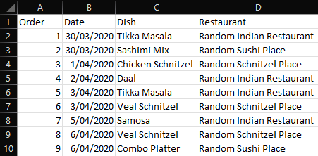

A **wide format** spreads a variable across multiple columns. For example, we can spread the “Dish” column across three columns, each corresponding to a different value of the “Restaurant” column:

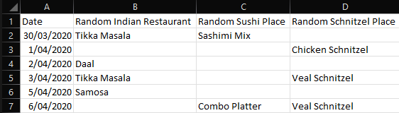

Both long and wide formats can be useful for different purposes, and one or the other may be more intuitive during data collection depending on the nature of the data and the research question being considered. Occasionally, datasets may even include a mix of long and wide data, and this is usually what we will spend most of our time arranging and adjusting when preparing data for analysis. Some programming languages, libraries and packages will handle data in wide format, others in long format, and converting between the two can be extremely time consuming when a dataset is not constructed with the proper analytical pipeline in mind.

We will usually construct our datasets in long format, also known as **tidy format**. This is the easiest format to use in R. In this format, each *column* represents a single *variable*, each *row* represents a single *observation*, and each *cell* represents a single *value* – always remember this when you are constructing a dataset and want to double-check if your data are in a long, wide, or mixed format.

```r
head(data1)
```

```
##   Population Time Rep Alive Dead  Taste Colour Stickyness Hat_or_no_hat
## 1  Brunswick  24h   1     5   10  Sweet    Red        Low        No Hat
## 2  Brunswick  24h   2     6    9  Salty  Green       High           Hat
## 3  Brunswick  24h   3     5   10   Sour Yellow     Medium        No Hat
## 4  Brunswick  24h   4     6    9 Bitter Orange        Low           Hat
## 5  Brunswick  24h   5     9    6  Umami Purple     Medium           Hat
## 6  Brunswick  24h   6     5   10  Sweet   Blue       High        No Hat
##   Crop_type Season Jealousy Leg_number Shoe_number
## 1     Apple Summer      Low          4           8
## 2      Corn   Fall Moderate          2           6
## 3     Lemon Spring     High          4           7
## 4    Orange Winter      Low          2           9
## 5  Eggplant Summer Moderate          4           8
## 6 Blueberry   Fall Moderate          2           6
```

```r
str(data1)
```

```
## 'data.frame':    144 obs. of  14 variables:
##  $ Population   : chr  "Brunswick" "Brunswick" "Brunswick" "Brunswick" ...
##  $ Time         : chr  "24h" "24h" "24h" "24h" ...
##  $ Rep          : int  1 2 3 4 5 6 7 8 9 10 ...
##  $ Alive        : int  5 6 5 6 9 5 8 7 9 8 ...
##  $ Dead         : int  10 9 10 9 6 10 7 8 6 7 ...
##  $ Taste        : chr  "Sweet" "Salty" "Sour" "Bitter" ...
##  $ Colour       : chr  "Red" "Green" "Yellow" "Orange" ...
##  $ Stickyness   : chr  "Low" "High" "Medium" "Low" ...
##  $ Hat_or_no_hat: chr  "No Hat" "Hat" "No Hat" "Hat" ...
##  $ Crop_type    : chr  "Apple" "Corn" "Lemon" "Orange" ...
##  $ Season       : chr  "Summer" "Fall" "Spring" "Winter" ...
##  $ Jealousy     : chr  "Low" "Moderate" "High" "Low" ...
##  $ Leg_number   : int  4 2 4 2 4 2 4 2 4 2 ...
##  $ Shoe_number  : int  8 6 7 9 8 6 7 9 8 6 ...
```

Survival was scored at multiple times during the experiment. Today, we will only consider survival at the last scoring time.

### Identify the latest scoring time using `distinct()` and then use `filter()` to create a new dataset that excludes all other scoring times.

```r
distinct(data1, Time)
```

```
##   Time
## 1  24h
## 2  48h
## 3  72h
```

```r
data2 <- filter(data1, Time == '72h')
str(data2)
```

```
## 'data.frame':    48 obs. of  14 variables:
##  $ Population   : chr  "Brunswick" "Brunswick" "Brunswick" "Brunswick" ...
##  $ Time         : chr  "72h" "72h" "72h" "72h" ...
##  $ Rep          : int  1 2 3 4 5 6 7 8 9 10 ...
##  $ Alive        : int  6 6 5 7 6 8 7 6 8 9 ...
##  $ Dead         : int  9 9 10 8 9 7 8 9 7 6 ...
##  $ Taste        : chr  "Sweet" "Salty" "Sour" "Bitter" ...
##  $ Colour       : chr  "Red" "Green" "Yellow" "Orange" ...
##  $ Stickyness   : chr  "Low" "High" "Medium" "Low" ...
##  $ Hat_or_no_hat: chr  "No Hat" "Hat" "No Hat" "Hat" ...
##  $ Crop_type    : chr  "Apple" "Corn" "Lemon" "Orange" ...
##  $ Season       : chr  "Summer" "Fall" "Spring" "Winter" ...
##  $ Jealousy     : chr  "Low" "Moderate" "High" "Low" ...
##  $ Leg_number   : int  4 2 4 2 4 2 4 2 4 2 ...
##  $ Shoe_number  : int  8 6 7 9 8 6 7 9 8 6 ...
```

```r
table(data1$Population)
```

```
##
## Brunswick   Carlton    Coburg Northcote
##        36        36        36        36
```

Raw data often contain more information that what we need (*e.g.*, extra traits and general notes) that can make things messy.

Today, we are only interested in 5 columns: Population, Rep, Time, Alive, Dead.

### Can you use the `select()` function to create a new dataset that only includes these 5 coloumns?

```r
data3 <- select(data2, 'Population', 'Rep', 'Time', 'Alive', 'Dead')
head(data3)
```

```
##   Population Rep Time Alive Dead
## 1  Brunswick   1  72h     6    9
## 2  Brunswick   2  72h     6    9
## 3  Brunswick   3  72h     5   10
## 4  Brunswick   4  72h     7    8
## 5  Brunswick   5  72h     6    9
## 6  Brunswick   6  72h     8    7
```

We are interested in the survival rate of our critters but we only have the number alive and dead per replicate reported in the dataset.

### We can use the `mutate()` function to create a new dataset with the coloumn for survival rate.

```r
data4 <- mutate(data3, Survival = Alive / (Alive + Dead))
```

We have now created our "Final" dataset that is ready for analysis. However, doing so also required us to create 3 new and separate datasets along the way... All these extra datasets can add up and create confusion, especially when they have uninformative names like data1, data2, data3, *etc*. Luckily there is a better way!

### We can use pipes `%>%` to complete all previous steps in a single line of code!

Pipes are a pretty intuitive way of writing code. The pipe's usage is `LHS %>% RHS`, meaning you move what is written on the left-hand side (LHS) of the pipe into the first argument of the function on the right-hand side (RHS).

[figure not shown]

This allows you to get around R's native and clumsy way of using many (many) nested parentheses, and write code as you would the English language, left to write. Think of it as "take object *x*, then perform action *y* on it, then perform action *z* on it", *etc*.

So, instead of doing this (clumsy, difficult to follow):

```r
filter(
  select(
    mutate(data1,
           Survival = Alive/ (Alive + Dead)),
    'Population', 'Rep', 'Time', 'Alive', 'Dead', 'Survival'),
  Time == '72h')
```

```
##    Population Rep Time Alive Dead   Survival
## 1   Brunswick   1  72h     6    9 0.40000000
## 2   Brunswick   2  72h     6    9 0.40000000
## 3   Brunswick   3  72h     5   10 0.33333333
## 4   Brunswick   4  72h     7    8 0.46666667
## 5   Brunswick   5  72h     6    9 0.40000000
## 6   Brunswick   6  72h     8    7 0.53333333
## 7   Brunswick   7  72h     7    8 0.46666667
## 8   Brunswick   8  72h     6    9 0.40000000
## 9   Brunswick   9  72h     8    7 0.53333333
## 10  Brunswick  10  72h     9    6 0.60000000
## 11  Brunswick  11  72h     8    7 0.53333333
## 12  Brunswick  12  72h     7    8 0.46666667
## 13    Carlton   1  72h     1   14 0.06666667
## 14    Carlton   2  72h     3   12 0.20000000
```

[output cut: 34 more lines]

You just do this (neat, intuitive):

```r
data1 %>%
  filter(Time == '72h') %>%
  select('Population', 'Rep', 'Time', 'Alive', 'Dead') %>%
  mutate(Survival = Alive/ (Alive + Dead))
```

```
##    Population Rep Time Alive Dead   Survival
## 1   Brunswick   1  72h     6    9 0.40000000
## 2   Brunswick   2  72h     6    9 0.40000000
## 3   Brunswick   3  72h     5   10 0.33333333
## 4   Brunswick   4  72h     7    8 0.46666667
## 5   Brunswick   5  72h     6    9 0.40000000
## 6   Brunswick   6  72h     8    7 0.53333333
## 7   Brunswick   7  72h     7    8 0.46666667
## 8   Brunswick   8  72h     6    9 0.40000000
## 9   Brunswick   9  72h     8    7 0.53333333
## 10  Brunswick  10  72h     9    6 0.60000000
## 11  Brunswick  11  72h     8    7 0.53333333
## 12  Brunswick  12  72h     7    8 0.46666667
## 13    Carlton   1  72h     1   14 0.06666667
## 14    Carlton   2  72h     3   12 0.20000000
```

[output cut: 34 more lines]

Notice that the outputs are exactly the same, it's just an easier way of getting to the same solution. Now, save this as a new object and let's move on:

```r
data5 <- data1 %>%
  filter(Time == '72h') %>%
  select('Population', 'Rep', 'Time', 'Alive', 'Dead') %>%
  mutate(Survival = Alive/ (Alive + Dead))
```

## Summarising data

Let's get some answers from our data!

### Find the average survival rate using `summarise()`

```r
data5 %>%
  summarise(mean(Survival))
```

```
##   mean(Survival)
## 1      0.2738803
```

Let's say we want to know the average survival for each population.

### Calculate the average suvrvival of each population by using piping to add `group_by()` to the code above.

```r
data5 %>%
  group_by(Population) %>%
  summarise(mean(Survival))
```

```
## # A tibble: 4 × 2
##   Population `mean(Survival)`
##   <chr>                 <dbl>
## 1 Brunswick            0.461
## 2 Carlton              0.282
## 3 Coburg               0.290
## 4 Northcote            0.0619
```

The `group_by()` function is a really useful one. It creates groups in your data.frame based on all unique values of a selected variable (column). Then, every function you run on the data.frame will run on the groups separately. This can either have no effect, or a huge effect, depending on which function you run.

When you run `group_by()`, notice the grouping variables (and number of groups) are now explicitly listed:

```r
data5 %>%
  group_by(Population)
```

```
## # A tibble: 48 × 6
## # Groups:   Population [4]
##    Population   Rep Time  Alive  Dead Survival
##    <chr>      <int> <chr> <int> <int>    <dbl>
##  1 Brunswick      1 72h       6     9    0.4
##  2 Brunswick      2 72h       6     9    0.4
##  3 Brunswick      3 72h       5    10    0.333
##  4 Brunswick      4 72h       7     8    0.467
##  5 Brunswick      5 72h       6     9    0.4
##  6 Brunswick      6 72h       8     7    0.533
##  7 Brunswick      7 72h       7     8    0.467
##  8 Brunswick      8 72h       6     9    0.4
##  9 Brunswick      9 72h       8     7    0.533
## 10 Brunswick     10 72h       9     6    0.6
## # … with 38 more rows
```

There are four groups, because that is how many unique values there are in the `Population` column:

```r
unique(data5$Population)
```

```
## [1] "Brunswick" "Carlton"   "Coburg"    "Northcote"
```

Let's use the `slice_head()` function to show how `group_by()` works. `slice_head()` is used to select a few (top) rows from a data.frame. So, if we run:

```r
data5 %>%
  slice_head(n = 3)
```

```
##   Population Rep Time Alive Dead  Survival
## 1  Brunswick   1  72h     6    9 0.4000000
## 2  Brunswick   2  72h     6    9 0.4000000
## 3  Brunswick   3  72h     5   10 0.3333333
```

We get the first three rows of our data.frame. But, if we use `group_by()` first:

```r
data5 %>%
  group_by(Population) %>%
  slice_head(n = 3)
```

```
## # A tibble: 12 × 6
## # Groups:   Population [4]
##    Population   Rep Time  Alive  Dead Survival
##    <chr>      <int> <chr> <int> <int>    <dbl>
##  1 Brunswick      1 72h       6     9   0.4
##  2 Brunswick      2 72h       6     9   0.4
##  3 Brunswick      3 72h       5    10   0.333
##  4 Carlton        1 72h       1    14   0.0667
##  5 Carlton        2 72h       3    12   0.2
##  6 Carlton        3 72h       3    12   0.2
##  7 Coburg         1 72h       2    13   0.133
##  8 Coburg         2 72h       8     7   0.533
##  9 Coburg         3 72h       3    12   0.2
## 10 Northcote      1 72h       2    20   0.0909
## 11 Northcote      2 72h       1    13   0.0714
## 12 Northcote      3 72h       1    13   0.0714
```

Now we have the first three rows of each population! Neat.

One thing that is important to notice is that groups are inherited through each stage of the piping process. Even after running the function `slice_head()`, the grouping remains, and any subsequent function we run will still act on the groups. However, we can use `ungroup()` to remove the groups, and then run subsequent functions on the entire data.frame:

```r
data5 %>%
  group_by(Population) %>%
  slice_head(n = 3) %>%
  ungroup() %>%
  slice_head(n = 3)
```

```
## # A tibble: 3 × 6
##   Population   Rep Time  Alive  Dead Survival
##   <chr>      <int> <chr> <int> <int>    <dbl>
## 1 Brunswick      1 72h       6     9    0.4
## 2 Brunswick      2 72h       6     9    0.4
## 3 Brunswick      3 72h       5    10    0.333
```

Basically, we have a really powerful tool that allows us to manipulate our data using combinations of `group_by()`, `summarise()`, `ungroup()`, and other functions. We can create long pipes to do lots of cool data wrangling, and we can also group by several variables (for example `group_by(Population, Time)`) and ungroup by some, but not all, of the grouped variables (`ungroup(Population)`). We encourage you to play around with these functions to become comfortable with them, they are among the most powerful tools in the `tidyverse` arsenal.

### Using `count()`, find the total number of replicates of each population and the total number of individuals across all replicates.

```r
data5 %>%
  group_by(Population) %>%
  count()
```

```
## # A tibble: 4 × 2
## # Groups:   Population [4]
##   Population     n
##   <chr>      <int>
## 1 Brunswick     12
## 2 Carlton       12
## 3 Coburg        12
## 4 Northcote     12
```

You're right! Turns out there's an easier (and a harder) way to do this exercise.

The harder way is without the `count()` function. If we think about the operations we are doing here, we are grouping our data.frame by the Population variable, and then summarising - how many observations are there in each group? Counting things in base R is done using the `length()` function, or in the `dplyr` package using the `n()` function. The difference is that `length()` requires an input vector, which needs to be specified explicitly. `n()` is part of the `tidyverse`, so it fits neatly within its grammar, and infers the input vector from the previous steps in the pipe.

So, we can use either of these two options:

```r
data5 %>%
  group_by(Population) %>%
  summarise(n = length(Population))
```

```
## # A tibble: 4 × 2
##   Population     n
##   <chr>      <int>
## 1 Brunswick     12
## 2 Carlton       12
## 3 Coburg        12
## 4 Northcote     12
```

```r
data5 %>%
  group_by(Population) %>%
  summarise(n = n())
```

```
## # A tibble: 4 × 2
##   Population     n
##   <chr>      <int>
## 1 Brunswick     12
## 2 Carlton       12
## 3 Coburg        12
## 4 Northcote     12
```

But wait, if `tidyverse` already has `n()`, what's the point of `count()`? Turns out `count()` is a good example of the many quality-of-life improvements `tidyverse` has to offer over base R.

`df %>% count(a)` is equivalent to `df %>% group_by(a) %>% summarise(n = n())`. It's basically a function that wraps a bunch of other functions into it, and allows you to write neater, shorter code.

So we could have completed the above exercise using the much simpler

```r
data5 %>%
  count(Population)
```

```
##   Population  n
## 1  Brunswick 12
## 2    Carlton 12
## 3     Coburg 12
## 4  Northcote 12
```

### Using `summarise()`, find the total number of individuals tested within each population.

`mutate()` and `summarise()` can be used with complicated functions, that can accept multiple columns in the data.frame as input.

```r
data5 %>%
    group_by(Population) %>%
    summarise(total = sum(Alive, Dead))
```

```
## # A tibble: 4 × 2
##   Population total
##   <chr>      <int>
## 1 Brunswick    180
## 2 Carlton      169
## 3 Coburg       185
## 4 Northcote    199
```

Now we have the data all neat and tidy, let's save this version so we can send it to other people.

```r
write.csv(data5, 'cool_old_data.csv')
```

## Combining datasets

Oh cool, someone sent us some new data on growth rates! Let's add this to our existing dataset!

### Import the data

```r
data_new <- read.csv('Oh_cool_some_new_growth_data.csv')
```

### Have a look at your data.

Are your data long or wide?

```r
head(data_new)
```

```
##   Rep Brunswick Carlton Coburg Northcote
## 1   1         0       0      3         3
## 2   2         3       1      2         2
## 3   3         1       2      4         4
## 4   4         3       1      2         5
## 5   5         1       4      5         4
## 6   6         4       1      3         3
```

```r
str(data_new)
```

```
## 'data.frame':    12 obs. of  5 variables:
##  $ Rep      : int  1 2 3 4 5 6 7 8 9 10 ...
##  $ Brunswick: int  0 3 1 3 1 4 3 3 5 4 ...
##  $ Carlton  : int  0 1 2 1 4 1 2 1 5 2 ...
##  $ Coburg   : int  3 2 4 2 5 3 2 1 0 0 ...
##  $ Northcote: int  3 2 4 5 4 3 3 1 1 2 ...
```

The new data have a different format (wide) to your old data (long). Before we can combine them, we need them to be in the same format.

### Convert `data_new` to a long format.

```r
data_size <- data_new %>%
  pivot_longer(cols = c('Brunswick', 'Carlton', 'Coburg', 'Northcote'),
               names_to = "Population" ,
               values_to = "Growth")

data_size
```

```
## # A tibble: 48 × 3
##      Rep Population Growth
##    <int> <chr>       <int>
##  1     1 Brunswick       0
##  2     1 Carlton         0
##  3     1 Coburg          3
##  4     1 Northcote       3
##  5     2 Brunswick       3
##  6     2 Carlton         1
##  7     2 Coburg          2
##  8     2 Northcote       2
##  9     3 Brunswick       1
## 10     3 Carlton         2
## # … with 38 more rows
```

Yes!

The `pivot_wider()` function does the exact opposite of `pivot_longer()`.

```r
data_size %>%
  pivot_wider(names_from = "Population",
              values_from = "Growth")
```

```
## # A tibble: 12 × 5
##      Rep Brunswick Carlton Coburg Northcote
##    <int>     <int>   <int>  <int>     <int>
##  1     1         0       0      3         3
##  2     2         3       1      2         2
##  3     3         1       2      4         4
##  4     4         3       1      2         5
##  5     5         1       4      5         4
##  6     6         4       1      3         3
##  7     7         3       2      2         3
##  8     8         3       1      1         1
##  9     9         5       5      0         1
## 10    10         4       2      0         2
## 11    11         4       1      1         0
## 12    12         4       3      4         0
```

Using these two functions you can easily switch your data between long and wide formats. This is useful because even though most analyses and visualisation in R use long data, some things are easier to do on wide data. For example, let's say we want to add 5 to all growth values in the Brunswick population, but not in the other populations. This be easily accomplished in wide data, and we can use piping to do a quick transformation to wide, run this operation, then switch back:

```r
data_size %>%
  pivot_wider(names_from = "Population",
              values_from = "Growth") %>%
  mutate(Brunswick = Brunswick + 5) %>%
  pivot_longer(cols = c('Brunswick', 'Carlton', 'Coburg', 'Northcote'),
               names_to = "Population" ,
               values_to = "Growth")
```

```
## # A tibble: 48 × 3
##      Rep Population Growth
##    <int> <chr>       <dbl>
##  1     1 Brunswick       5
##  2     1 Carlton         0
##  3     1 Coburg          3
##  4     1 Northcote       3
##  5     2 Brunswick       8
##  6     2 Carlton         1
##  7     2 Coburg          2
##  8     2 Northcote       2
##  9     3 Brunswick       6
## 10     3 Carlton         2
## # … with 38 more rows
```

Confused about what exactly happened? Try running each step separately to see what they do.

You can achieve the same thing without transforming your data from long to wide, but this would require incorporating `if()` statements or using `case_when()` within `mutate()`, and creating somewhat more complex functions than just X + 5. At the end, it's up to you to try out different options and choose whichever fits your coding style best. R is versatile, and there are often multiple solutions to a single problem.

### Combine the two datsets using one of the `join()` functions.

```r
df_fin <- left_join(data5, data_size, by = c('Population', 'Rep'))
```

`tidyverse` has several functions available to join data.frames. They all share a similar syntax, which requires the following arguments:

- `x` - the first data.frame
- `y` - the second data.frame
- `by` - which columns to join by

The functions then look across all values of the column specific in `by` in data.frame `x`, and search for in the column specified in `by` in data.frame `y` based on the columns provided in `by`. If a match is found, all values in the matching row from the other columns of either `x` or `y` or both are combined, depending on the join function you used. If no matches are found, then `NA` is returned. This can happen when you are combining datasets with incomplete information - for example, if `y` has a population that is missing from `x`.

The four join functions are:

- `inner_join()`: includes all rows in `x` and `y`.
- `left_join()`: includes all rows in `x`.
- `right_join()`: includes all rows in `y`.
- `full_join()`: includes all rows in `x` or `y`.

`inner_join()` will never return `NA`s. If no matches are found, the row is dropped.

`left_join()` and `right_join()` are equivalent to using Excel's VLOOKUP function to add values from `y` to `x`, or to add values from `x` to `y`, respectively. Only unlike Excel, it does this over all columns, instead of just one. `NA`s can occur for missing matches. So for example, if you use `left_join()` by column `a` and `x` has values of `a` that don't exist in `y`, those rows will have `NA` in all columns from `y`.

`full_join()` fully combines the two data.frames, and `NA` values can show up in columns from both `x` and `y` if there are values of the joining column `a` in `x` that don't appear in `y` and *vice versa*.

By the way, a good way to anticipate if joins will result in `NA`s, or to explore why you got `NA`s, is to compare the two data.frames for mismatched values. `tidyverse` has a bunch of handy functions to compare elements of two vectors, such as `intersect()`, `union()`, or `setdiff()`. It's worth exploring these.

[figure not shown]

### Can you create a plot of survival as a function of growth?

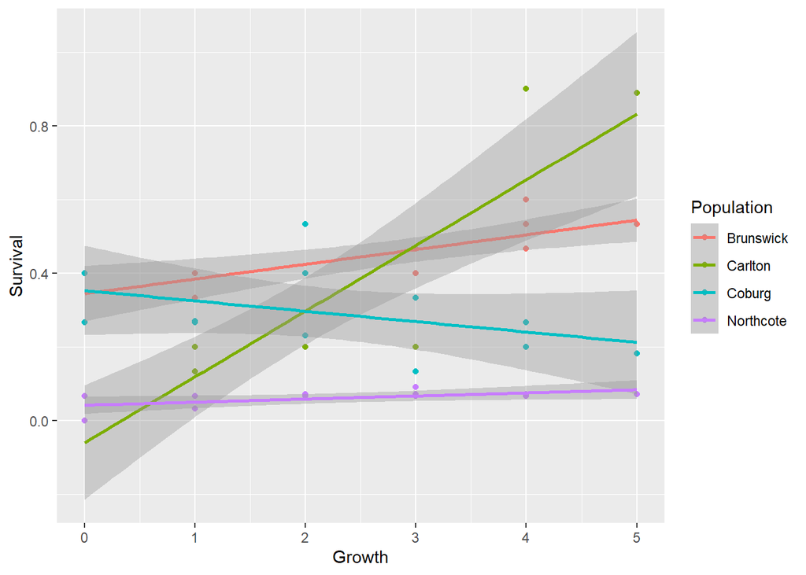

```r
df_fin %>%
  ggplot(aes(x = Growth, y = Survival, colour = Population)) +
  geom_point() +
  geom_smooth(method = "lm")
```

R is amazing for data visualisation. And especially `tidyverse`, using the extremely powerful `ggplot2` package.

[figure not shown]

However, using `ggplot2` is a massive package with a lot of options and uses. We're not opening this can of worms right now. But if you found this workshop useful, let us know! We might be able to put on another workshop focusing on data visualisation.

### Useful resources

If you don't know how to do something in R, there are several useful places you can search for answers:

First step is always https://www.google.com - chances are high someone has already run into the same issue as you, and an answer can be found online by googling it.

[figure not shown]

Googling will likely lead you to https://stackoverflow.com/ - this another useful resource where you can post questions about code and get answers from the community. Note that not everyone is particularly nice on StackOverflow, and some people can have a pretty nasty attitude towards beginners. However, the R community is genuinely much more welcoming than other coding communities.

[figure not shown]

You can also look in https://r4ds.hadley.nz/ - the second edition of R for Data Science. This is a free online book that includes everything you may need to know about R, from the absolute basics to some pretty high-end stuff like writing your own functions and iteration. This book was written by Hadley Wickham, the man behind tidyverse, so it fits well with what we've covered in this workshop.

[figure not shown]

Finally, there's always https://chat.openai.com/ - ChatGPT can be handy because it can often write functioning R code from basic questions in simple English. However, it's not always correct, and may write code that *looks* correct, but actually is a hot mess. Use with caution, and always double-check what it gives you.

[figure not shown]